# Samson_HW5

Danielle Samson

2025-12-01

## Choose a city to work with

In the following chunk, I read in the data, looked through the list of potential cities then decided to work with Denver. I then filtered the dataset to include only the data from Denver and used the provided coordinates to turn the dataframe into a simple feature object. Finally, I generated the plot to help visualize where I am and where I need to go with my code

```r
library(tidyverse)
library(sf)
library(tigris)
library(ggthemes)
#read in the data

homicides <- read.csv("homicide-data.csv")

#choose a city

print(unique(homicides$city))
```

```
##  [1] "Albuquerque"    "Atlanta"        "Baltimore"      "Baton Rouge"
##  [5] "Birmingham"     "Boston"         "Buffalo"        "Charlotte"
##  [9] "Chicago"        "Cincinnati"     "Columbus"       "Dallas"
## [13] "Denver"         "Detroit"        "Durham"         "Fort Worth"
## [17] "Fresno"         "Houston"        "Indianapolis"   "Jacksonville"
## [21] "Kansas City"    "Las Vegas"      "Long Beach"     "Los Angeles"
## [25] "Louisville"     "Memphis"        "Miami"          "Milwaukee"
## [29] "Minneapolis"    "Nashville"      "New Orleans"    "New York"
## [33] "Oakland"        "Oklahoma City"  "Omaha"          "Philadelphia"
## [37] "Phoenix"        "Pittsburgh"     "Richmond"       "San Antonio"
## [41] "Sacramento"     "Savannah"       "San Bernardino" "San Diego"
## [45] "San Francisco"  "St. Louis"      "Stockton"       "Tampa"
## [49] "Tulsa"          "Washington"
```

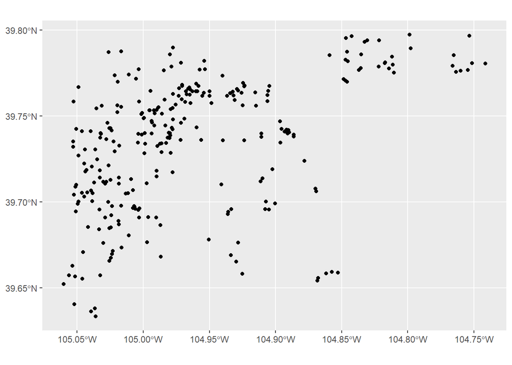

```r
denver_homicides <- homicides %>%
  filter(city == 'Denver') %>%
  st_as_sf(coords = c("lon", "lat"),
               crs = 4269)

#evaluate the current plot

denver_homicides %>%
  ggplot() +
  geom_sf()
```

## Input city boundaries

In this chunk, I took the Colorado geometry from the tigris package and then filtered the data to include only Denver. Looking back, I think I could have done this in one step by immediately filtering by the NAME column. Again, I checked in on the plot

```r
#extract denver boundaries from tigris
places <- tigris::places(state = "CO",
                                    cb = FALSE,
                                    year = "2024")
denver_boundaries <- places %>%
  filter(NAME == "Denver")
```

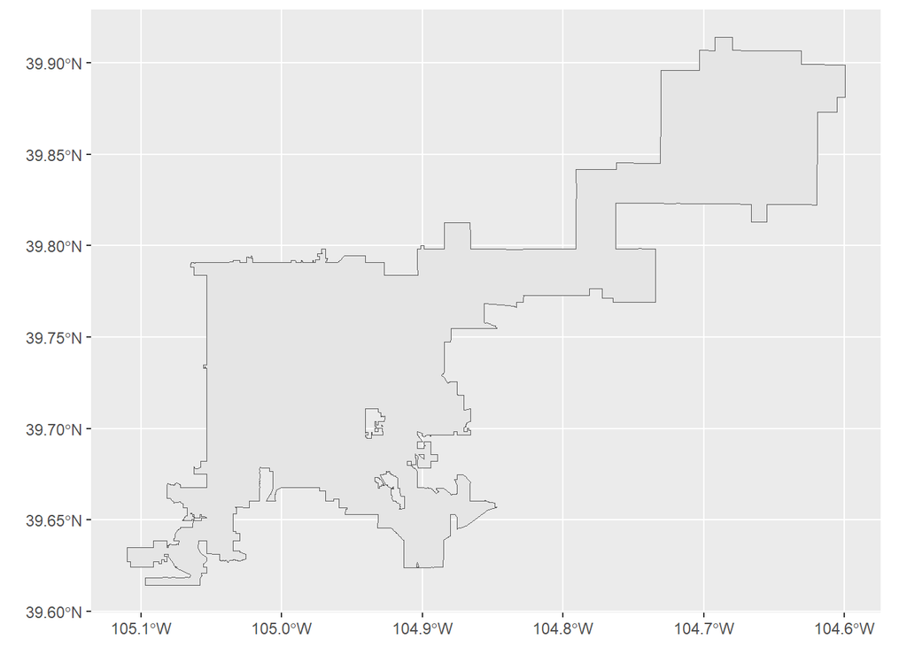

```r
denver_boundaries %>%
  ggplot() +
  geom_sf()
```

## Align Geometries

In this chunk, I ensure that my geometries align before continuing to manipulate my dataset

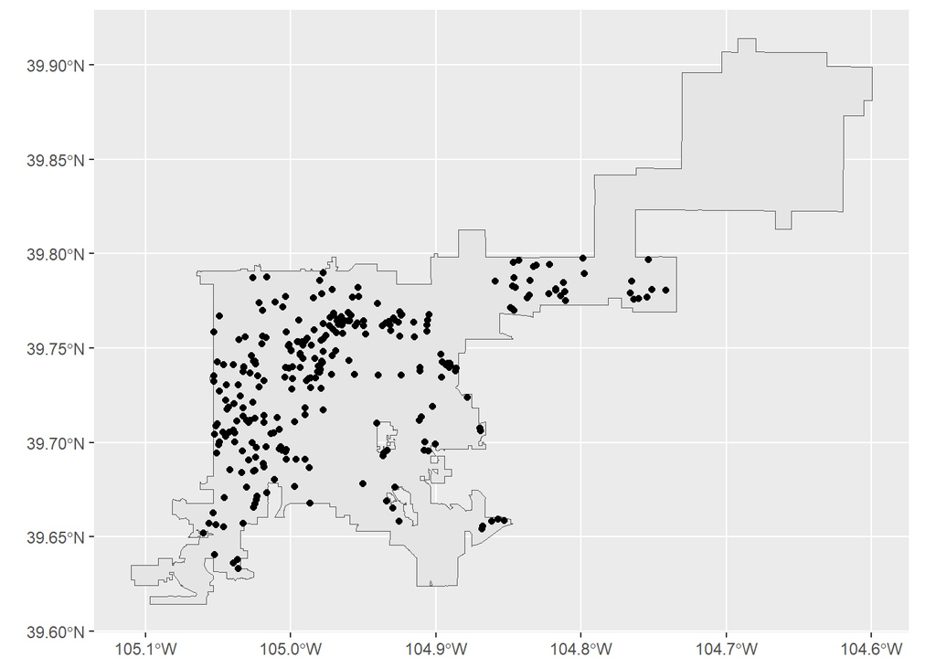

```r
ggplot() +
  geom_sf(data = denver_boundaries) +
  geom_sf(data = denver_homicides)
```

## Factor Lump to Most Murdered Races

In this chunk, I convert the victim_race column to a factor to be used with the fct_lump function to highlight the races with the most murders. I then visualize the status of the plot

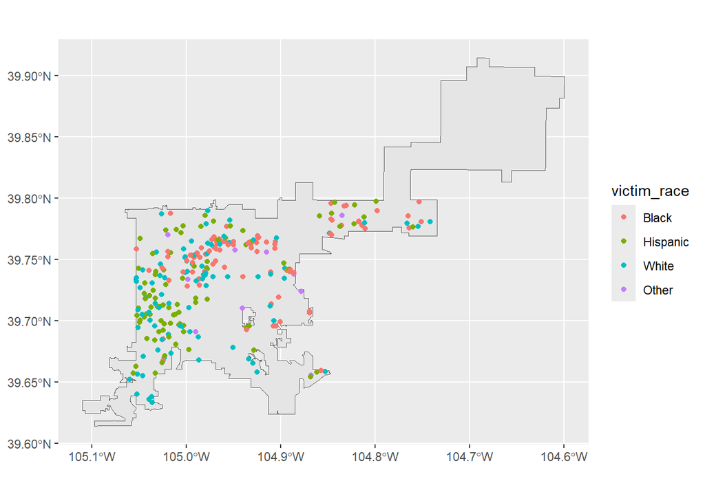

```r
denver_victim_races <- denver_homicides %>%
  mutate(victim_race = as.factor(victim_race)) %>%
  mutate(victim_race = fct_lump(victim_race, n = 3))

ggplot() +
  geom_sf(data = denver_boundaries) +
  geom_sf(data = denver_victim_races, aes(color = victim_race))
```

## Unsolved cases

In this chunk, I create a new column to sort the cases by solved vs unsolved

```r
#solved vs unsolved columns
case_status <- denver_victim_races %>%
  mutate(solved = ifelse(disposition %in% c("Closed without arrest", "Closed by arrest"), "Solved", "Unsolved"))
```

## Final Plot

This chunk generates the final plot with maps separated by solved and unsolved cases

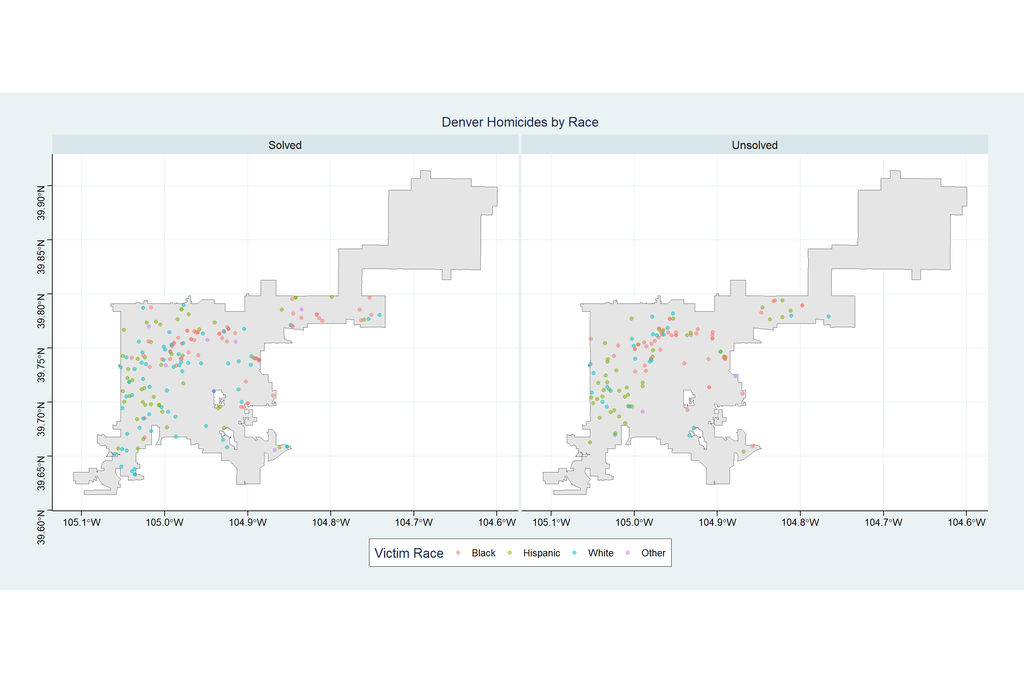

```r
ggplot() +
  geom_sf(data = denver_boundaries) +
  geom_sf(data = case_status, aes(color = victim_race), alpha = 0.5) +
  facet_wrap("solved") +
  theme_stata() +
  labs(
    title = "Denver Homicides by Race",
    color = "Victim Race"
  )
```